# Problem Set 3

Due date: 25 September

Please upload your completed assignment to the ELMs course site (under the assignments menu) and to your class Github repository. You need to upload both your Quarto document (with R code, as needed) and its rendered output (either as a PDF or HTML file).

**Total points: 30**

**Kennedy Lighty**

```r
library(tidyverse)
library(wbstats)
library(poliscidata)
library(countrycode)
library(broom)
library(janitor)
library(ggridges)
library(modelsummary)
library(dplyr)
```

```r
dem_wealth_df <- readr::read_csv("http://svmiller.com/extdata/democracy-income-1950.csv") |>
  dplyr::transmute(iso3c, country, gdp_per_cap = wbgdp2011est / wbpopest, democracy_score = xm_qudsest)
```

The `dem_wealth_df` data set (taken from the wonderful Dr Steven V Miller’s [blog post](https://svmiller.com/blog/2023/09/democracy-income-correlation-analysis/)) will help us explore the relationship between a country’s level of democracy and its citizens’ wealth in 1950. It is a replication of [Lipset (1959)](https://www.cambridge.org/core/journals/american-political-science-review/article/abs/some-social-requisites-of-democracy-economic-development-and-political-legitimacy1/26559429359F42D3E9B8BC82CA65546A). Miller uses Xavier Marquez’s [measure for democracy](https://www.cambridge.org/core/journals/political-analysis/article/democratic-compromise-a-latent-variable-analysis-of-ten-measures-of-regime-type/2A6B2BBA6F80367644F2C5007E1CFC29). This is a great (if complicated) measure. For this problem set, you only need to know that a country’s level of democracy increases with its “democracy score”.

## Question 1

### Part A

*Points: 2*

**Note**

2/2

> Using the `dem_wealth_df` data frame loaded in above, produce a scatter plot of the variables `democracy_score` and `gdp_per_cap` (with `gdp_per_cap` as the dependent variable on the y-axis). Professionally format your graph.

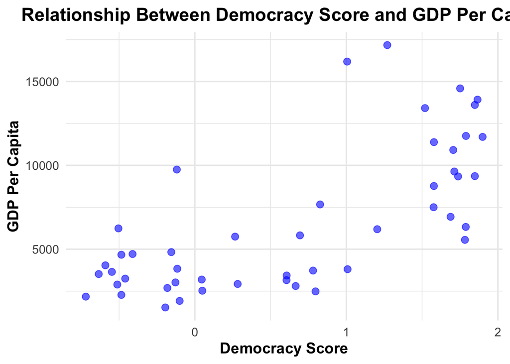

```r
ggplot(data = dem_wealth_df, aes(x = democracy_score, y = gdp_per_cap)) +
    geom_point(color = "blue", size = 3, alpha = 0.6) +
    labs(title = "Relationship Between Democracy Score and GDP Per Capita",
         x = "Democracy Score",
         y = "GDP Per Capita") +
    theme_minimal(base_size = 15) +
    theme(
        plot.title = element_text(hjust = 0.5, face = "bold"),
        axis.title.x = element_text(face = "bold"),
        axis.title.y = element_text(face = "bold")
    )
```

### Part B

*Points: 3*

**Note**

1.5/3

> Describe the scatter plot. Note suspected outliers if any exist (a visual inspection will suffice for this question).

**The scatter plot shows a positive relationship between the X axis and the Y axis. This positive relationship suggest that as the democracy score increases so does the GDP per capita.**

**Note**

Be careful not to use causal language. Better to say: democracies tend to be wealthier than non-democracies.

**There are also many clusters in the data, these clusters indicate that countries share similar levels of democracy and GDP per capita.**

**Note**

Are there any outliers?

## Question 2

Calculate the correlation coefficient between democracy_score and gdp_per_cap. What does it tell you about the relationship between a country’s level of democracy and its citizens’ wealth?

*Points: 2*

**Note**

2/2

```r
 correlation <- cor(dem_wealth_df$democracy_score, dem_wealth_df$gdp_per_cap, use = "complete.obs")
```

**Note**

It is correlated!

## Question 3

I would like to know whether individuals with higher levels of education tend to pay greater levels of attention to politics than those with lower levels of education.

### Part A

*Points: 5*

**Note**

1/5, this is not a cross tab.

> Using the `nes` data set in the `polisciols` R package, construct a cross-tab of the relationship between `attention_to_politics` and `education`. Focus only on those respondents who provided answers (filter out “Refused”, “Don’t know”, and missing responses).

```r
data("nes", package = "polisciols")
 nes_filtered <- nes |>
     filter(attention_to_politics != "Refused",
            attention_to_politics != "Don't know",
            !is.na(attention_to_politics),
            education != "Refused",
            education != "Don't know",
            !is.na(education))

cross_tab <- table(nes_filtered$attention_to_politics, nes_filtered$education)

cross_tab_df <- as.data.frame(cross_tab)

cross_tab_df
```

```
                  Var1                                        Var2 Freq
1              Refused                                     Refused    0
2               Always                                     Refused    0
3     Most of the time                                     Refused    0
4  About half the time                                     Refused    0
5     Some of the time                                     Refused    0
6                Never                                     Refused    0
7              Refused                                  Don't know    0
8               Always                                  Don't know    0
9     Most of the time                                  Don't know    0
10 About half the time                                  Don't know    0
11    Some of the time                                  Don't know    0
12               Never                                  Don't know    0
13             Refused                                        <NA>    0
14              Always                                        <NA>   25
```

[output cut: 34 more lines]

### Part B

*Points: 3*

**Note**

1/3, correct but you cannot see this from the data as you have cut it.

> Describe the relationship between these two variables (if one exists).

## Question 4

*Points: 5*

**Note**

5/5

I hypothesize that US voters who identify as being religious are less likely to support Federal government funding of scientific research. To test this, I run a survey of a representative sample of the US voting population. I ask respondents to indicate how often they attend religious ceremonies as a proxy measure of how strongly they identify as religious. They can answer: never, only for significant events, or regularly. Next, I ask respondents whether they think the Federal government’s funding of scientific research is “too little”, “about right”, or “too much”.

> Describe how you would construct a cross-tab to evaluate my hypothesis. Which responses (religious identification or support for Federal funding) would you compare within? Relatedly, which would you vary? Finally, what statistics would you use to make your comparisons?

**I would create a cross-tab comparing religious identification (independent variable) with support for Federal funding of scientific research (dependent variable). Doing it this way will allow me to examine the opinions on federal funding across different levels of religious identification. Looking at each identification group I can compare how respondents differ in their support for government spending. Ex:  “Do those who attend religious ceremonies regularly show higher proportions of thinking funding is”too much” compared to those who never attend?” I would vary the level of identification because I am testing how different levels of religious identity can impact attitudes toward government spending.**

## Question 5

Let’s return to our original question of the relationship between democracy and individuals’ wealth.

### Part A

*Points: 2*

**Note**

2/2

> Create two new variables based on a country’s level of democracy, and its citizens’ wealth. For the democracy variable, split countries into three categories: `autocracy` if they score in the lowest third of democracy scores, `hybrid` if they score in the middle third, and `democracy` if they score in the highest third. Similarly, for the wealth variable, split countries into three categories: `low income` if they score in the lowest third of GDP per capita, `middle income` if they score in the middle third, and `high income` if they score in the highest third.

```r
dem_wealth_df <- dem_wealth_df |>
  mutate(
    democracy_category = case_when(
      democracy_score <= quantile(democracy_score, 1/3) ~ "autocracy",
      democracy_score > quantile(democracy_score, 1/3) & democracy_score <= quantile(democracy_score, 2/3) ~  "hybrid",
      democracy_score > quantile(democracy_score, 2/3) ~ "democracy"
    ),
    wealth_category = case_when(
      gdp_per_cap <= quantile(gdp_per_cap, 1/3) ~ "low income",
      gdp_per_cap > quantile(gdp_per_cap, 1/3) & gdp_per_cap <= quantile(gdp_per_cap, 2/3) ~ "Middle income",
      gdp_per_cap > quantile(gdp_per_cap, 2/3) ~ "High income"
    )
  )
```

### Part B

*Points: 3*

**Note**

3/3

> Create a cross-tab.

```r
datasummary_crosstab(
  democracy_category ~ wealth_category,
  data = dem_wealth_df
)
```

| democracy_category |  | High income | low income | Middle income | All |
| --- | --- | --- | --- | --- | --- |
| autocracy | N | 1 | 8 | 7 | 16 |
|  | % row | 6.2 | 50.0 | 43.8 | 100.0 |
| democracy | N | 12 | 0 | 4 | 16 |
|  | % row | 75.0 | 0.0 | 25.0 | 100.0 |
| hybrid | N | 3 | 8 | 5 | 16 |
|  | % row | 18.8 | 50.0 | 31.2 | 100.0 |
| All | N | 16 | 16 | 16 | 48 |
|  | % row | 33.3 | 33.3 | 33.3 | 100.0 |

### Part C

*Points: 5*

**Note**

4/5

> Describe the relationship between these variables.

**Autocratic nations typically fall into both the lower and middle economic ranges. This implies a variety of economic circumstances under autocratic governments. Most democracies fall into one of two income categories: middle-class or upper-class. With countries represented in low, middle, and high income groups, hybrid regimes are more evenly spread across the income range. This is a reflection of the diverse political characteristics and economic standing of governments.**

**Note**

What is the general relationship? Do democracies tend to be wealthier than non-democracies?